# 135_Project1

Richard Ly

1/29/2022

# 1 Introduction

In this report we proceed with exploratory data analysis on a provided dataset. The dataset contains 4 quantitative variables, and 1 categorical variable. The categorical variable separates the data between two populations: bankrupt firms and non-bankrupt firms.

In this report, we dedicate sections to Materials and Results, References, and an Appendix containing all code used.

In the Materials and Results section, we explore for each of the two populations’ quantitative variables: summary statistics, highly correlated variables, pairwise scatter plots, side-by-side histograms, discriminating effects, normality, and outliers.

# 2 Materials and Results

- $X_1 = \frac{CF}{TD} = \frac{\mbox{cash flow}}{\mbox{total debt}}$
- $X_2 = \frac{NI}{TA} = \frac{\mbox{net income}}{\mbox{total assets}}$
- $X_3 = \frac{CA}{CL} = \frac{\mbox{current assets}}{\mbox{current liability}}$
- $X_4 = \frac{CA}{NS} = \frac{\mbox{current assets}}{\mbox{net sales}}$

## 2.1 Summary Statistics

Below are some summary statistics for bankrupt and non-bankrupt firms.

### 2.1.1 Bankrupt Firms

```r
summary(bankrupt)
```

```
##        x1                 x2                 x3              x4
##  Min.   :-0.56000   Min.   :-0.41000   Min.   :0.330   Min.   :0.1600
##  1st Qu.:-0.14000   1st Qu.:-0.14000   1st Qu.:1.190   1st Qu.:0.2700
##  Median :-0.07000   Median :-0.06000   Median :1.370   Median :0.4000
##  Mean   :-0.06905   Mean   :-0.08143   Mean   :1.367   Mean   :0.4376
##  3rd Qu.: 0.06000   3rd Qu.: 0.02000   3rd Qu.:1.510   3rd Qu.:0.6000
##  Max.   : 0.37000   Max.   : 0.11000   Max.   :2.150   Max.   :0.9500
```

```r
mean_bankrupt
```

```
## [1] -0.06904762 -0.08142857  1.36666667  0.43761905
```

### 2.1.2 Non-Bankrupt Firms

```r
summary(non_bankrupt)
```

```
##        x1                x2                x3              x4
##  Min.   :-0.3300   Min.   :-0.0900   Min.   :0.460   Min.   :0.1300
##  1st Qu.: 0.1400   1st Qu.: 0.0400   1st Qu.:2.050   1st Qu.:0.3300
##  Median : 0.1900   Median : 0.0600   Median :2.350   Median :0.4500
##  Mean   : 0.2352   Mean   : 0.0556   Mean   :2.594   Mean   :0.4268
##  3rd Qu.: 0.3800   3rd Qu.: 0.0800   3rd Qu.:2.920   3rd Qu.:0.5400
##  Max.   : 0.5800   Max.   : 0.1400   Max.   :5.060   Max.   :0.6900
```

```r
mean_non_bankrupt
```

```
## [1] 0.2352 0.0556 2.5936 0.4268
```

## 2.2 Highly Correlated Variables

### 2.2.1 Bankrupt Firms

```r
cor_bankrupt
```

```
##            x1        x2        x3         x4
## x1 1.00000000 0.9353713 0.4050883 0.09350746
## x2 0.93537133 1.0000000 0.4429400 0.11246935
## x3 0.40508830 0.4429400 1.0000000 0.38303852
## x4 0.09350746 0.1124693 0.3830385 1.00000000
```

### 2.2.2 Non-Bankrupt Firms

```r
cor_non_bankrupt
```

```
##            x1         x2        x3          x4
## x1  1.0000000 0.80465138 0.3376352 -0.19027054
## x2  0.8046514 1.00000000 0.1721188  0.02341074
## x3  0.3376352 0.17211881 1.0000000  0.19637341
## x4 -0.1902705 0.02341074 0.1963734  1.00000000
```

For non-bankrupt firms, $X_1$ and $X_2$ are highly positively correlated.

## 2.3 Pairwise Scatter Plots

The pairwise scatter plots for the 4 quantitative variables are color coded by population, with `population = 0` corresponding to bankrupt firms, and `population = 1` corresponding to non-bankrupt firms.

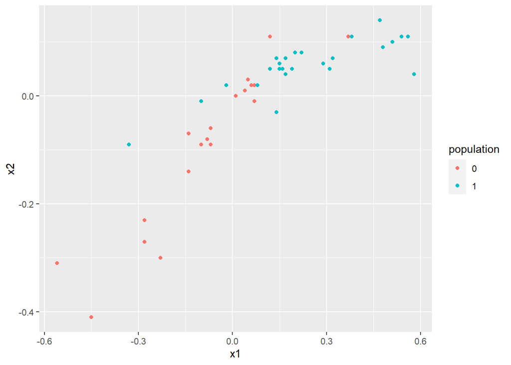

```r
ggplot(Project_1_Data, aes(x = x1, y = x2, color = population)) + geom_point()
```

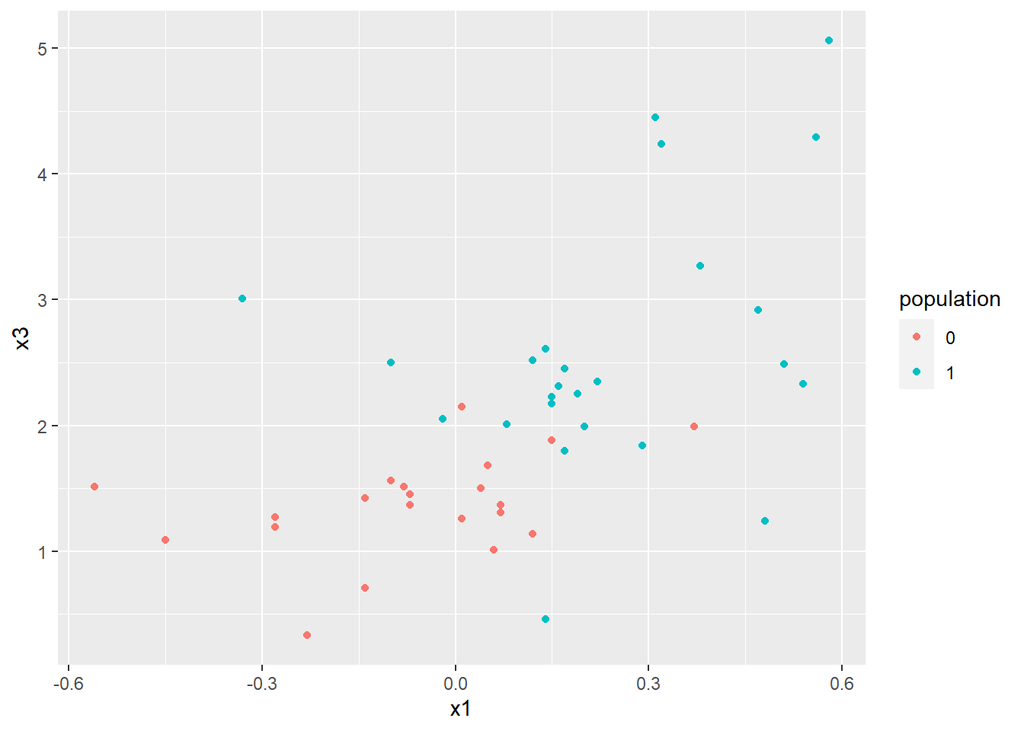

```r
ggplot(Project_1_Data, aes(x = x1, y = x3, color = population)) + geom_point()
```

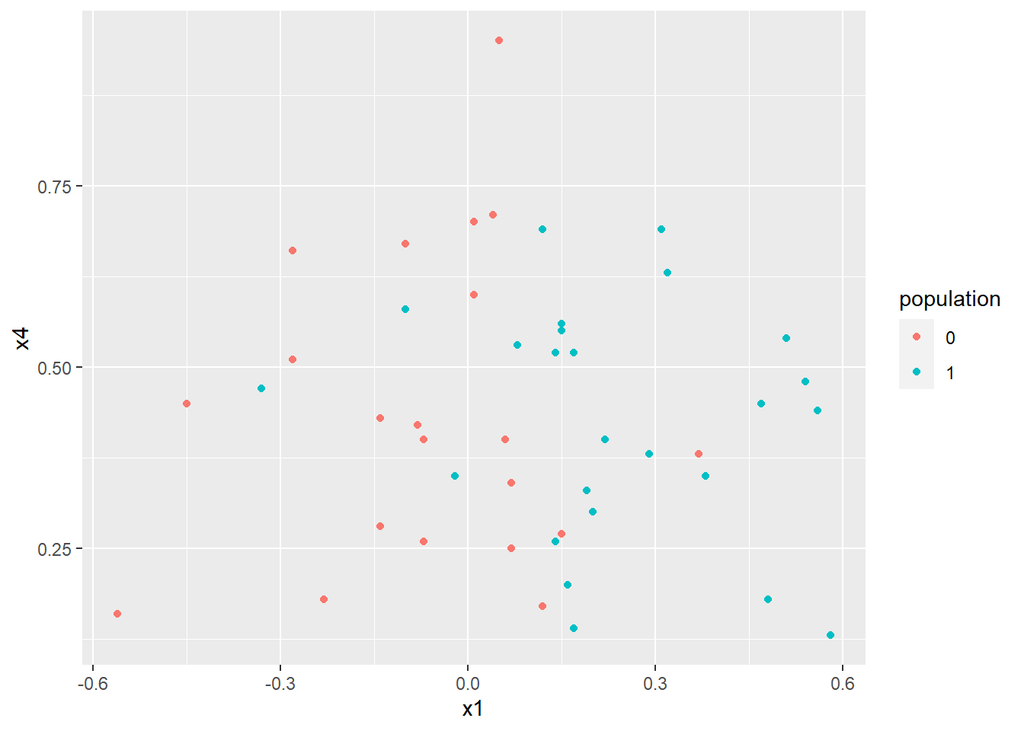

```r
ggplot(Project_1_Data, aes(x = x1, y = x4, color = population)) + geom_point()
```

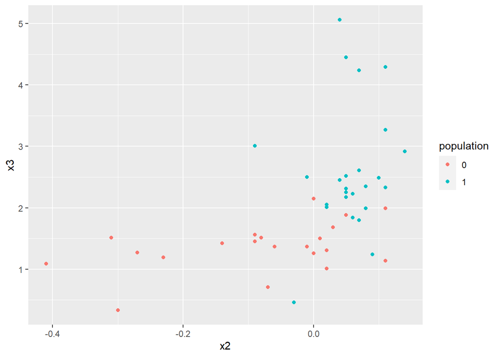

```r
ggplot(Project_1_Data, aes(x = x2, y = x3, color = population)) + geom_point()
```

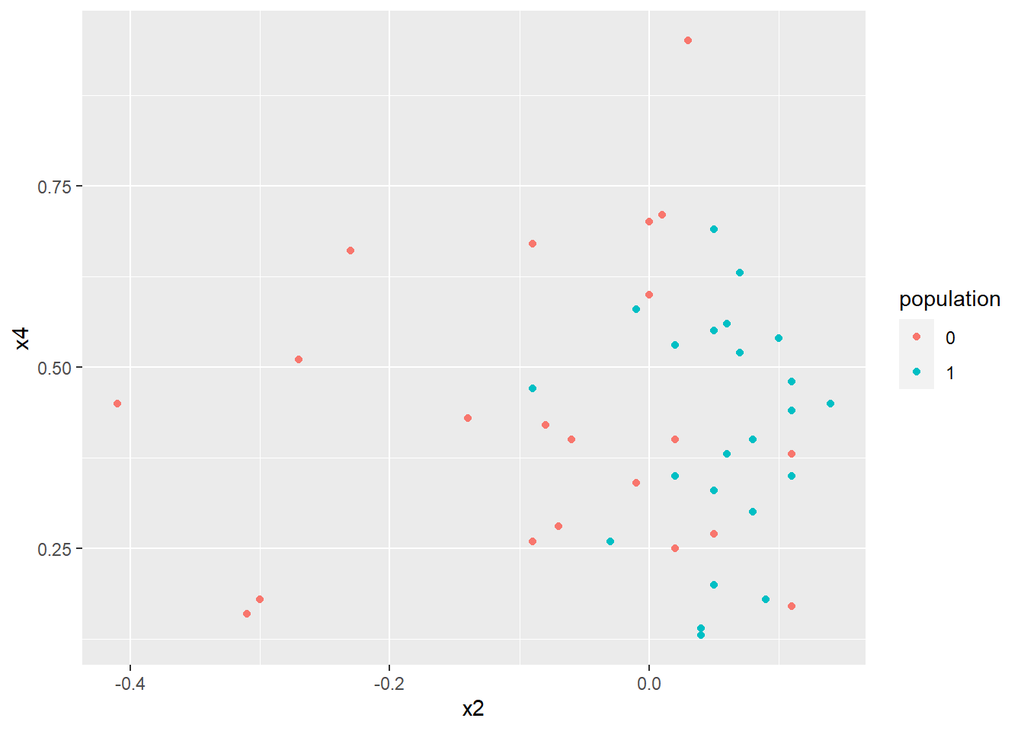

```r
ggplot(Project_1_Data, aes(x = x2, y = x4, color = population)) + geom_point()
```

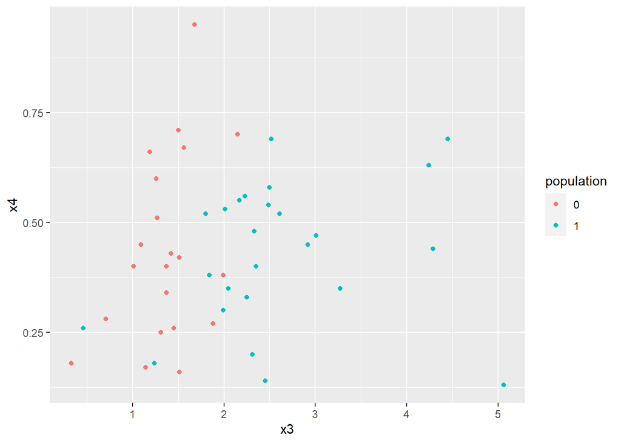

```r
ggplot(Project_1_Data, aes(x = x3, y = x4, color = population)) + geom_point()
```

## 2.4 Side-By-Side Histograms

Histograms for bankrupt and non-bankrupt firms are put side-by-side for each quantitative variable.

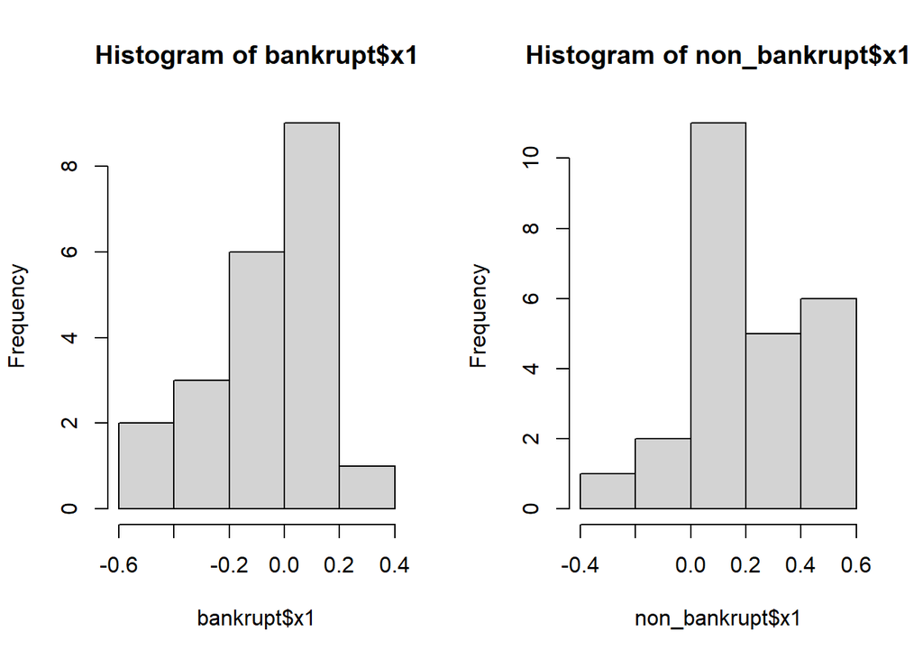

```r
par(mfrow=c(1,2))

hist(bankrupt$x1)
hist(non_bankrupt$x1)
```

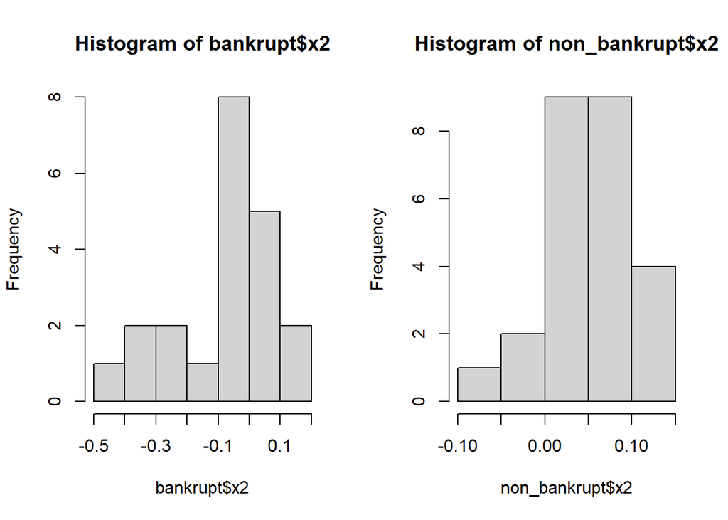

```r
hist(bankrupt$x2)
hist(non_bankrupt$x2)
```

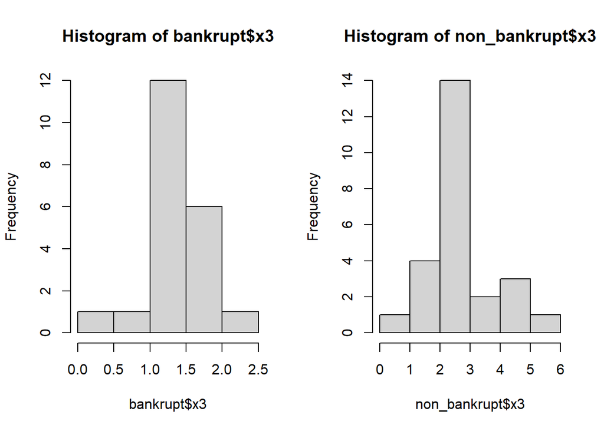

```r
hist(bankrupt$x3)
hist(non_bankrupt$x3)
```

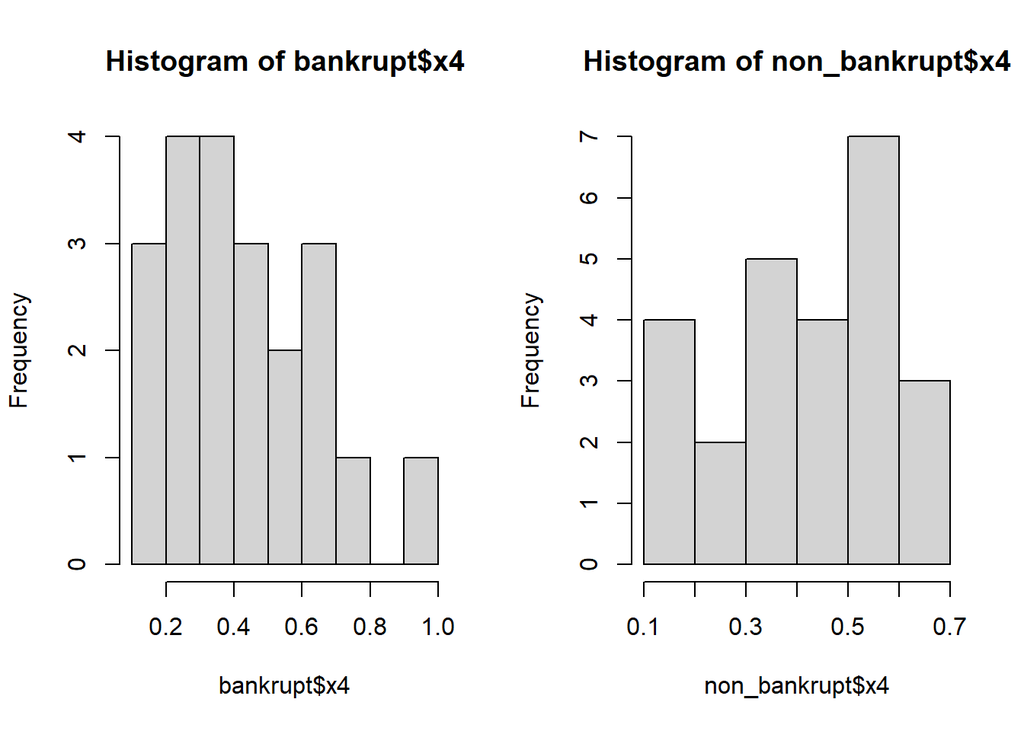

```r
hist(bankrupt$x4)
hist(non_bankrupt$x4)
```

## 2.5 Discriminating Effects

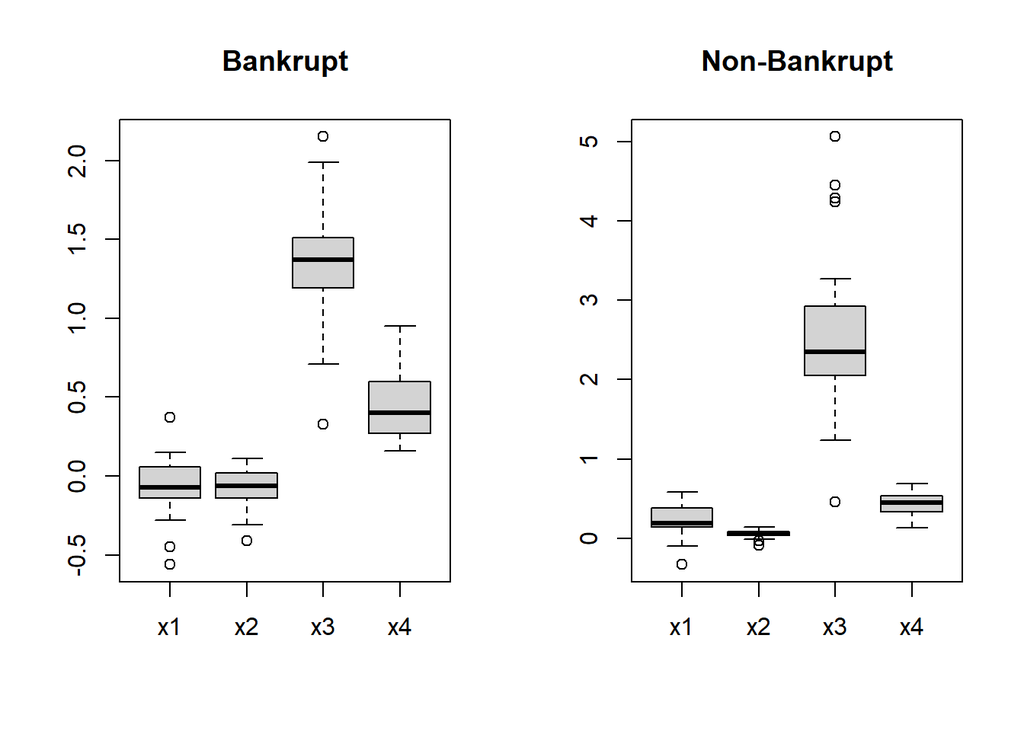

```r
par(mfrow=c(1,2))
boxplot(bankrupt, main = "Bankrupt")

boxplot(non_bankrupt, main = "Non-Bankrupt")
```

## 2.6 Normality

We can examine Normal Q-Q plots to check for the assumption of normality. To verify normality for each of the variables, we can use the Shapiro-Wilks test to obtain p-values. At the $\alpha$ level of significance, we reject the hypothesis of normality if a variable’s p-value is less than $\alpha$.

### 2.6.1 Bankrupt Firms

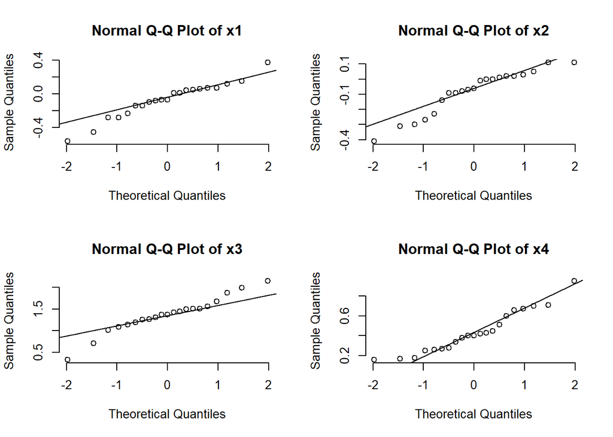

```r
par(mfrow=c(2,2))
for(i in colnames(bankrupt[,1:4])){
qqnorm(bankrupt[,i], frame = F, main = paste("Normal Q-Q Plot of ", i, sep = ""))
qqline(bankrupt[,i])
}
```

Here, we choose $\alpha = 0.1$ for the Shapiro-Wilks test.

```r
SW_pvalue_bankrupt
```

```
##                x1         x2       x3        x4
## p.value 0.4800084 0.05705832 0.505715 0.1920879
```

Variables $X_1,X_3,X_4$ have p-values greater than $\alpha = 0.1$ so the three variables satisfy the assumption of normality. $X_2$ has a p-value less than $\alpha = 0.1$ so it fails to satisfy the assumption of normality.

### 2.6.2 Non-Bankrupt Firms

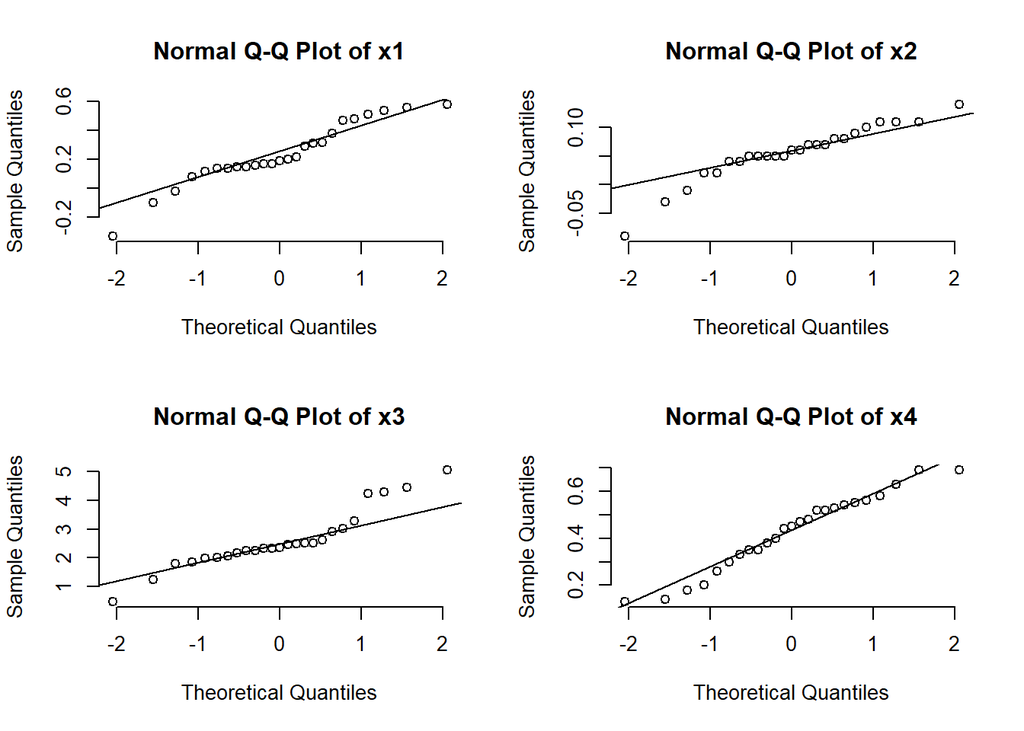

```r
par(mfrow=c(2,2))
for(i in colnames(non_bankrupt[,1:4])){
qqnorm(non_bankrupt[,i], frame = F, main = paste("Normal Q-Q Plot of ", i, sep = ""))
qqline(non_bankrupt[,i])
}
```

Here, we choose $\alpha = 0.1$ for the Shapiro-Wilks test.

```r
SW_pvalue_non_bankrupt
```

```
##                x1         x2         x3        x4
## p.value 0.1620325 0.06264929 0.02670764 0.4429486
```

Variables $X_1$ and $X_4$ have p-values greater than $\alpha = 0.1$ so the two variables satisfy the assumption of normality. $X_2$ and $X_3$ have p-values less than $\alpha = 0.1$ so they fail to satisfy the assumption of normality.

## 2.7 Outliers

### 2.7.1 Bankrupt Firms

```r
bankrupt_IndexOutliers
```

```
## $x1
## [1]  1  2 16
##
## $x2
## [1] 1
##
## $x3
## [1] 11 13
##
## $x4
## integer(0)
```

We find outliers for:

- $X_1$ in rows 1,2, and 16
- $X_2$ in row 1
- $X_3$ in rows 11 and 13

There are no outliers for $X_4$.

Note that these rows are the rows of `bankrupt`, not the original dataset.

### 2.7.2 Non-Bankrupt Firms

```r
non_bankrupt_IndexOutliers
```

```
## $x1
## [1] 19
##
## $x2
## [1] 13 19
##
## $x3
## [1]  5  6 13 21 25
##
## $x4
## integer(0)
```

We find outliers for:

- $X_1$ in row 19
- $X_2$ in rows 13 and 19
- $X_3$ in rows 5, 6, 13, 21, and 25

There are no outliers for $X_4$.

Note that these rows are the rows of `non_bankrupt`, not the original dataset.

# 3 References

Small parts of code were taken and modified from discussion lab pdf’s for Stats 135, written by Yan-Yu Chen and Ju-Sheng Hong.

Function `myOutliers` was taken from Stats 135 Piazza, written by Ju-Sheng Hong.

# 4 Appendix

```r
Project_1_Data <- read.csv("C:/Users/rly75/OneDrive/Desktop/135/Project_1_Data.txt", sep="")
Project_1_Data$population = as.factor(Project_1_Data$population)
```

```r
bankrupt = Project_1_Data[Project_1_Data$population=="0",1:4]
non_bankrupt = Project_1_Data[Project_1_Data$population=="1",1:4]
```

```r
summary(bankrupt)
```

```
##        x1                 x2                 x3              x4
##  Min.   :-0.56000   Min.   :-0.41000   Min.   :0.330   Min.   :0.1600
##  1st Qu.:-0.14000   1st Qu.:-0.14000   1st Qu.:1.190   1st Qu.:0.2700
##  Median :-0.07000   Median :-0.06000   Median :1.370   Median :0.4000
##  Mean   :-0.06905   Mean   :-0.08143   Mean   :1.367   Mean   :0.4376
##  3rd Qu.: 0.06000   3rd Qu.: 0.02000   3rd Qu.:1.510   3rd Qu.:0.6000
##  Max.   : 0.37000   Max.   : 0.11000   Max.   :2.150   Max.   :0.9500
```

```r
summary(non_bankrupt)
```

```
##        x1                x2                x3              x4
##  Min.   :-0.3300   Min.   :-0.0900   Min.   :0.460   Min.   :0.1300
##  1st Qu.: 0.1400   1st Qu.: 0.0400   1st Qu.:2.050   1st Qu.:0.3300
##  Median : 0.1900   Median : 0.0600   Median :2.350   Median :0.4500
##  Mean   : 0.2352   Mean   : 0.0556   Mean   :2.594   Mean   :0.4268
##  3rd Qu.: 0.3800   3rd Qu.: 0.0800   3rd Qu.:2.920   3rd Qu.:0.5400
##  Max.   : 0.5800   Max.   : 0.1400   Max.   :5.060   Max.   :0.6900
```

```r
mean_bankrupt = c(mean(bankrupt$x1),mean(bankrupt$x2),mean(bankrupt$x3),mean(bankrupt$x4))
mean_bankrupt
```

```
## [1] -0.06904762 -0.08142857  1.36666667  0.43761905
```

```r
mean_non_bankrupt = c(mean(non_bankrupt$x1),mean(non_bankrupt$x2),mean(non_bankrupt$x3),mean(non_bankrupt$x4))
mean_non_bankrupt
```

```
## [1] 0.2352 0.0556 2.5936 0.4268
```

```r
cor_bankrupt = cor(bankrupt)
cor_bankrupt
```

```
##            x1        x2        x3         x4
## x1 1.00000000 0.9353713 0.4050883 0.09350746
## x2 0.93537133 1.0000000 0.4429400 0.11246935
## x3 0.40508830 0.4429400 1.0000000 0.38303852
## x4 0.09350746 0.1124693 0.3830385 1.00000000
```

```r
cor_non_bankrupt = cor(non_bankrupt)
cor_non_bankrupt
```

```
##            x1         x2        x3          x4
## x1  1.0000000 0.80465138 0.3376352 -0.19027054
## x2  0.8046514 1.00000000 0.1721188  0.02341074
## x3  0.3376352 0.17211881 1.0000000  0.19637341
## x4 -0.1902705 0.02341074 0.1963734  1.00000000
```

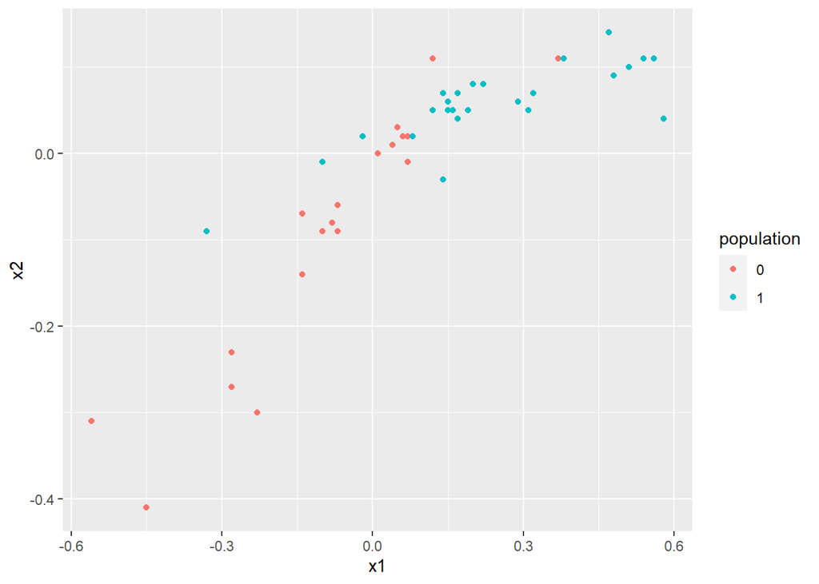

```r
library(ggplot2)
ggplot(Project_1_Data, aes(x = x1, y = x2, color = population)) + geom_point()
```

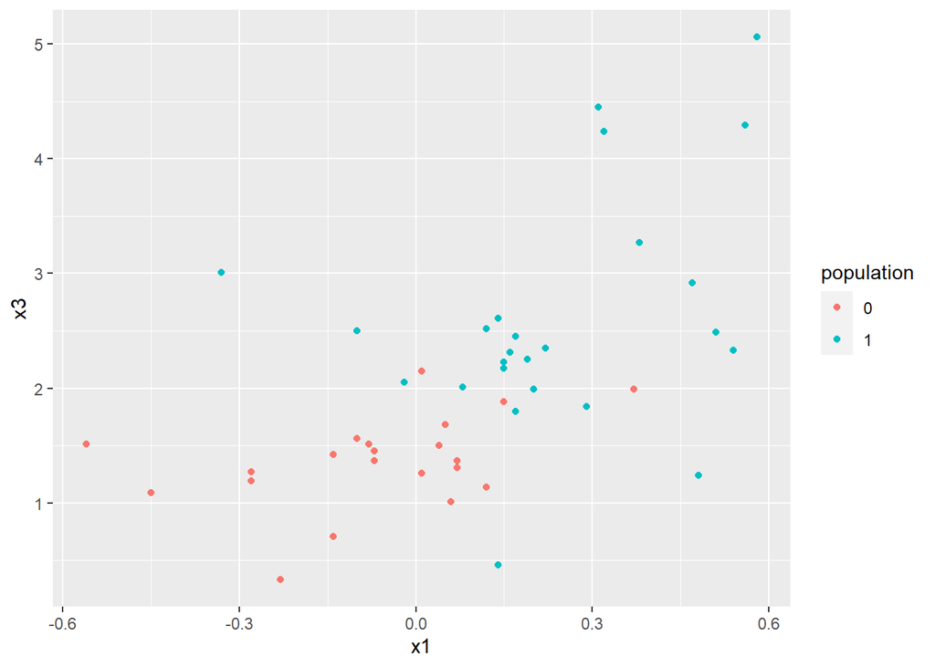

```r
ggplot(Project_1_Data, aes(x = x1, y = x3, color = population)) + geom_point()
```

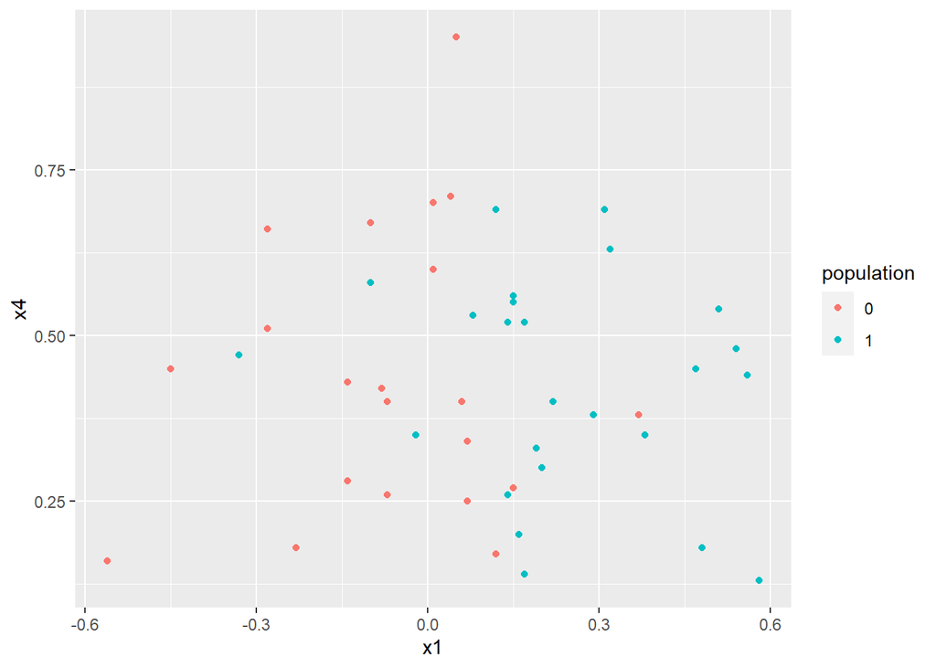

```r
ggplot(Project_1_Data, aes(x = x1, y = x4, color = population)) + geom_point()
```

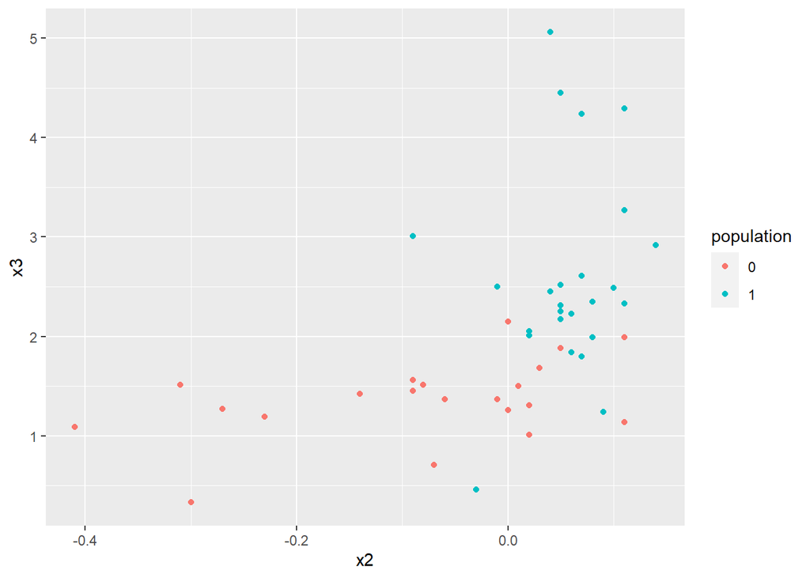

```r
ggplot(Project_1_Data, aes(x = x2, y = x3, color = population)) + geom_point()
```

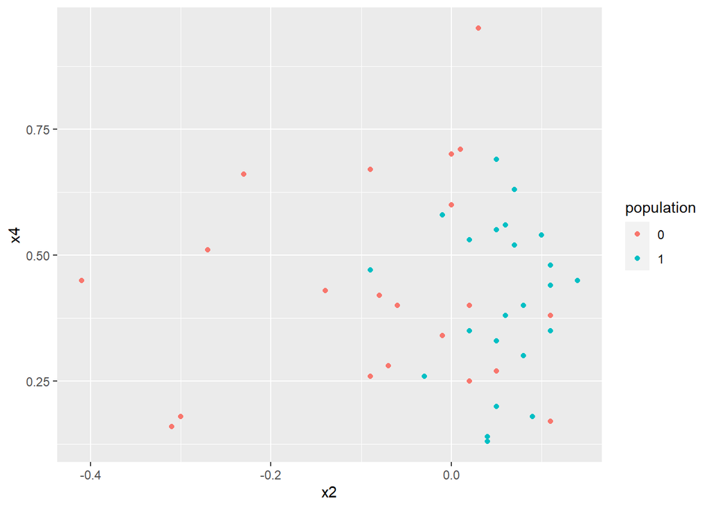

```r
ggplot(Project_1_Data, aes(x = x2, y = x4, color = population)) + geom_point()
```

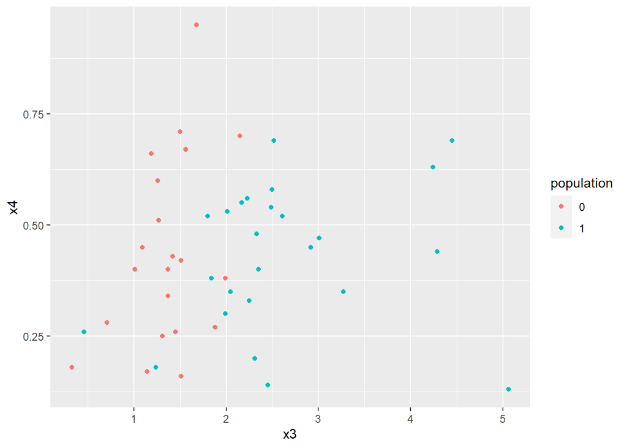

```r
ggplot(Project_1_Data, aes(x = x3, y = x4, color = population)) + geom_point()
```

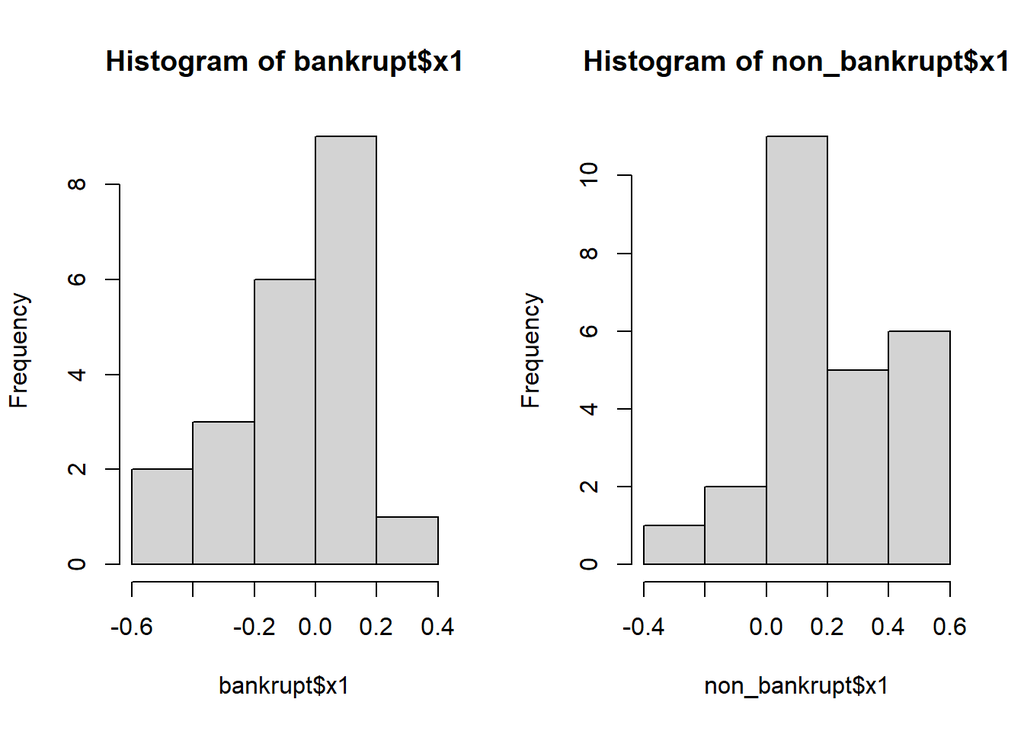

```r
par(mfrow=c(1,2))

hist(bankrupt$x1)
hist(non_bankrupt$x1)
```

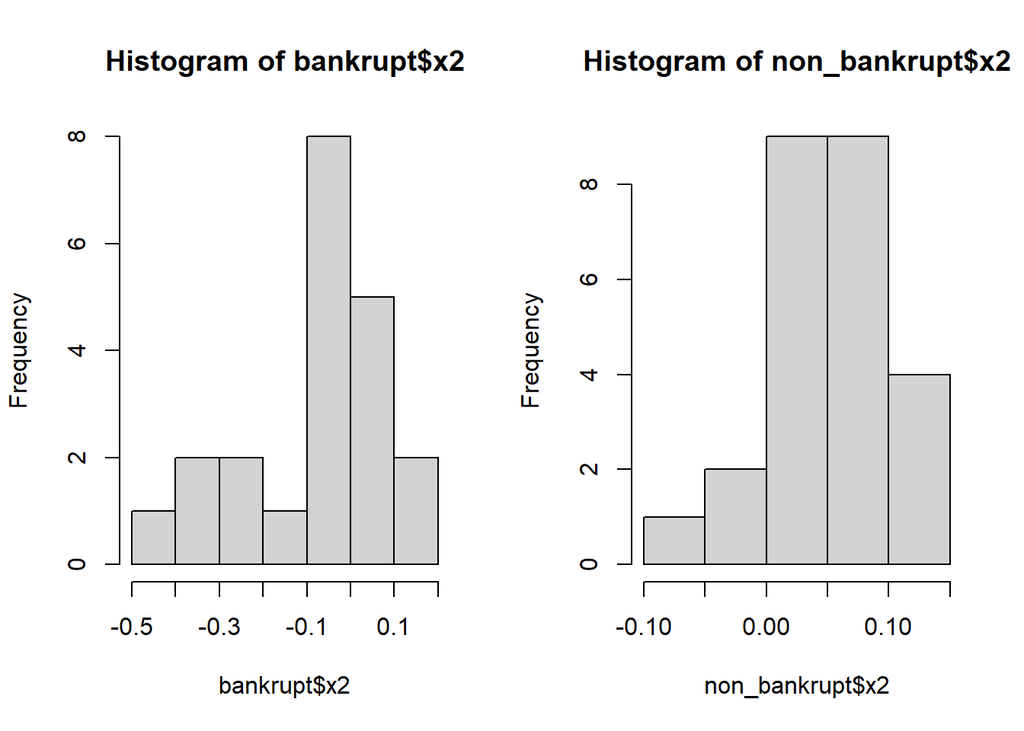

```r
hist(bankrupt$x2)
hist(non_bankrupt$x2)
```

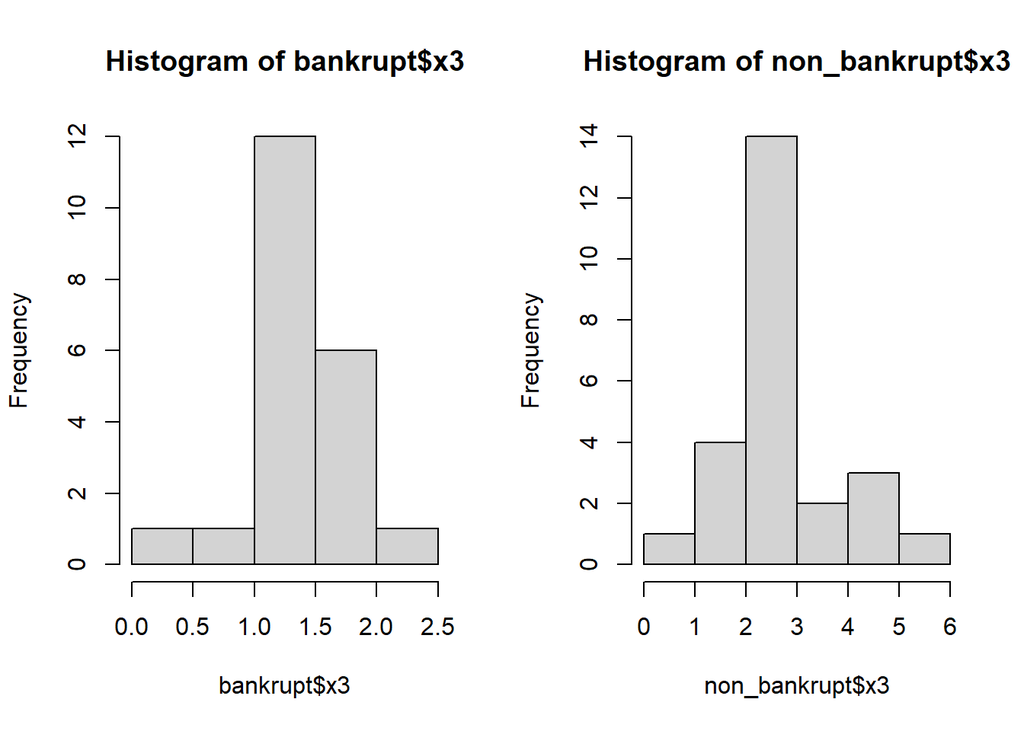

```r
hist(bankrupt$x3)
hist(non_bankrupt$x3)
```

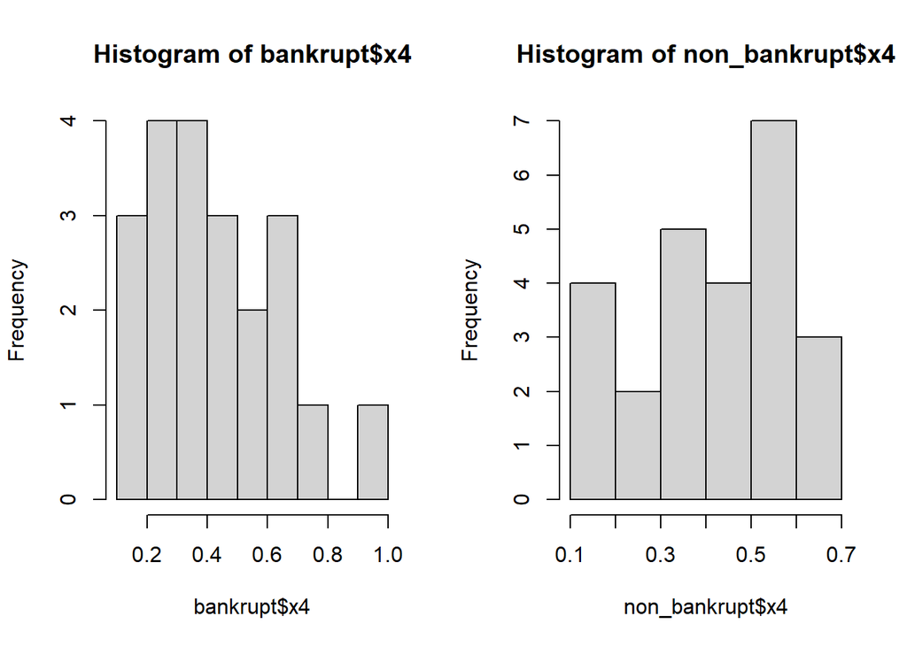

```r
hist(bankrupt$x4)
hist(non_bankrupt$x4)
```

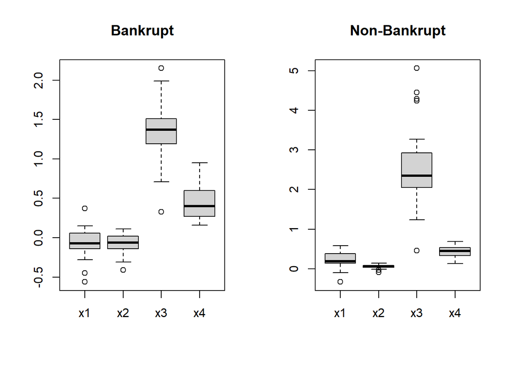

```r
par(mfrow=c(1,2))
boxplot(bankrupt, main = "Bankrupt")

boxplot(non_bankrupt, main = "Non-Bankrupt")
```

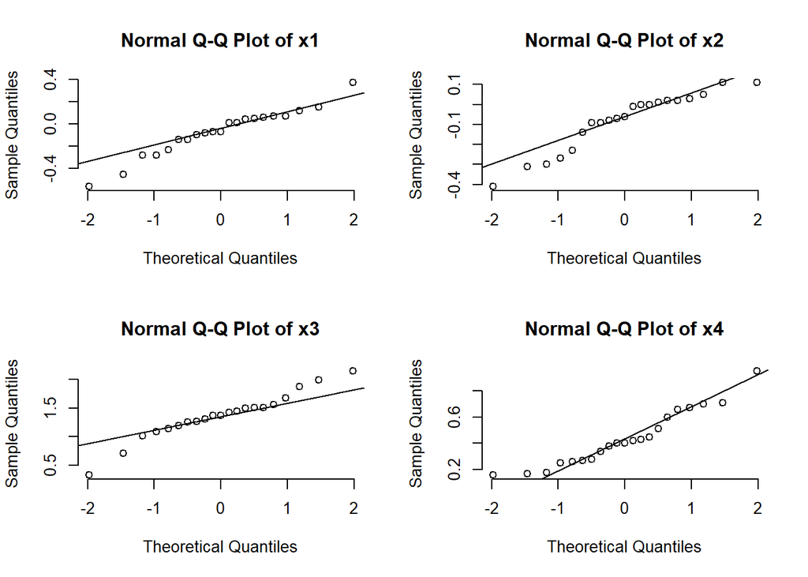

```r
par(mfrow=c(2,2))
for(i in colnames(bankrupt[,1:4])){
qqnorm(bankrupt[,i], frame = F, main = paste("Normal Q-Q Plot of ", i, sep = ""))
qqline(bankrupt[,i])
}
```

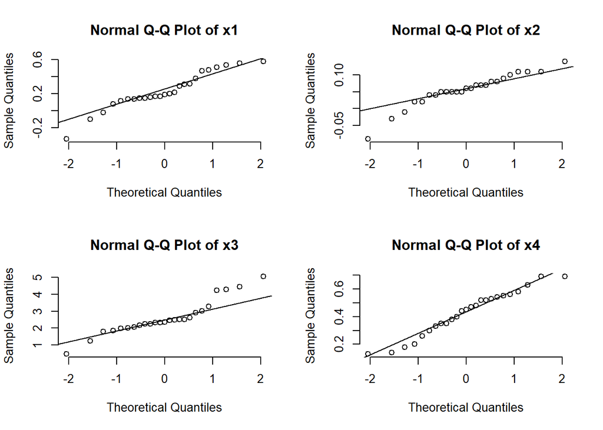

```r
for(i in colnames(non_bankrupt[,1:4])){
qqnorm(non_bankrupt[,i], frame = F, main = paste("Normal Q-Q Plot of ", i, sep = ""))
qqline(non_bankrupt[,i])
}
```

```r
SW_pvalue_bankrupt <- matrix(rep(NA, 4), nrow = 1, dimnames = list(c("p.value"), colnames(bankrupt)))
for(i in 1:4){
SW_pvalue_bankrupt[i] <- shapiro.test(bankrupt[,i])$p.value
}
SW_pvalue_bankrupt
```

```
##                x1         x2       x3        x4
## p.value 0.4800084 0.05705832 0.505715 0.1920879
```

```r
SW_pvalue_non_bankrupt <- matrix(rep(NA, 4), nrow = 1, dimnames = list(c("p.value"), colnames(non_bankrupt)))
for(i in 1:4){
SW_pvalue_non_bankrupt[i] <- shapiro.test(non_bankrupt[,i])$p.value
}
SW_pvalue_non_bankrupt
```

```
##                x1         x2         x3        x4
## p.value 0.1620325 0.06264929 0.02670764 0.4429486
```

```r
myOutliers = function(YourData){
  b.plot = boxplot(YourData, plot = FALSE)
  IndexOutliers = vector(mode = 'list', length = ncol(YourData))
  for(i in 1:ncol(YourData)){
    ColumnNow = YourData[, i]
    IndexOutliers[[i]] = which(ColumnNow %in% b.plot$out[b.plot$group == i])
  }

  if(is.null(colnames(YourData))){
    names(IndexOutliers) = paste("X", 1:ncol(YourData), sep = "")
  }else{
    names(IndexOutliers) = colnames(YourData)
  }

  return(IndexOutliers)
}

bankrupt_IndexOutliers = myOutliers(bankrupt)
bankrupt_IndexOutliers
```

```
## $x1
## [1]  1  2 16
##
## $x2
## [1] 1
##
## $x3
## [1] 11 13
##
## $x4
## integer(0)
```

```r
non_bankrupt_IndexOutliers = myOutliers(non_bankrupt)
non_bankrupt_IndexOutliers
```

```
## $x1
## [1] 19
##
## $x2
## [1] 13 19
##
## $x3
## [1]  5  6 13 21 25
##
## $x4
## integer(0)
```